# Lecture 08 - Forecasting AutoRegressive Process

[Nao Mimoto](http://gozips.uakron.edu/~nmimoto/) - [Dept. of Statistics](http://www.uakron.edu/stat/) : [The University of Akron](http://www.uakron.edu)

Jan 29 2018

[Class Web Page](http://gozips.uakron.edu/~nmimoto/477/index.html)

[R resource page](http://gozips.uakron.edu/~nmimoto/R/index.html)

# 1. Forecasting AR(p)

## Best Linear Predictor for AR(p)

- Given data $X_1, \ldots, X_n$, we want to predict $X_{n+1}$.
- Let $\hat X(1)$ be 1-step predictor given $X_1, \ldots, X_n$.
  - We only consider linear predictor
    $$\hat X(1) = a_0 + a_1 X_n + \cdots + a_n X_1$$
  - We define ‘best predictor’ as predictor that has minumim prediction MSE.
    $$\mbox{MSE} = E \Big[\big(\hat X(1) - X_{n+1}\big)^2\Big].$$
- Let $n=4$ for simplicity. Then $h-$step linear predictor is
  $$\hat X(h) = a_0 + a_1 X_4 + a_2 X_3 + a_3 X_2 + a_4 X_1$$
  We wanto to find coefficients $\{a_0,a_1, \ldots, a_n\}$ that minimize MSE,
  $$E \Big[(\hat X(h) - X_{n+h})^2\Big]
  = E \Big[\big( a_0 + a_1 X_n + \cdots + a_n X_1 - X_{n+h}\big)^2\Big].$$
  To do that, we’ll take $\frac{\partial }{ \partial a_i}$, and set them equal to 0.

**First,**

- we take $\frac{\partial }{ \partial a_0}$. Letting it go inside the expectation,
  $$\begin{align}
  \frac{\partial } { \partial a_0} E \Big[(\hat X(h) - X_{n+h})^2 \Big]
  & = \hspace3mm \frac{\partial } { \partial a_0}
  E \Big[ ( a_0 + a_1 X_4 + a_2 X_3 + a_3 X_2 + a_4 X_1 \hspace2mm - \hspace2mm X_{4+h})^2 \Big] \\\\
  & = \hspace3mm E \Big[2 ( a_0 + a_1 X_4 + a_2 X_3 + a_3 X_2 + a_4 X_1 \hspace2mm - \hspace2mm X_{4+h}) \Big] \\\\
  & = \hspace3mm 2 a_0 + 2 a_1 E\big[ X_4 \big] + 2 a_2 E\big[ X_3 \big] + 2 a_3 E\big[ X_2 \big] + 2 a_4 E\big[ X_1 \big] \hspace2mm - \hspace2mm E\big[ X_{4+h}\big] \\\\
  & = \hspace3mm 0
  \end{align}$$
- That means, since $E(X_t)=0$,
  $$2a_0 \hspace3mm = \hspace3mm 0 \hspace10mm \mbox{ or, } \hspace10mm a_0 = 0.$$

**Second,**

- Plugging in $a_0=0$, now we take $\frac{\partial } { \partial a_1}$. We have
  $$\begin{align}
  \frac{\partial } { \partial a_1} E \Big[(\hat X(h) - X_{n+h})^2\Big]
  & = \hspace3mm \frac{\partial } { \partial a_1} E \Big[ ( a_1 X_4 + a_2 X_3 + a_3 X_2 + a_4 X_1 \hspace2mm - \hspace2mm X_{4+h})^2 \Big] \\\\
  & = \hspace3mm E \Big[2 ( a_1 X_4 + a_2 X_3 + a_3 X_2 + a_4 X_1 \hspace2mm - \hspace2mm X_{4+h}) \,\, X_4 \Big] \\ \\
  & = 0
  \end{align}$$
- We can rewrite this, and get
  $$a_1 \gamma(0) + a_2 \gamma(1) + a_3 \gamma(2) + a_4 \gamma(3) - \gamma(h) = 0,$$
  or
  $$a_1 \gamma(0) + a_2 \gamma(1) + a_3 \gamma(2) + a_4 \gamma(3) = \gamma(h) .$$

**Third,**

- Now take $\frac{\partial } { \partial a_2}$. We have
  $$\frac{\partial } { \partial a_2} E \Big[(\hat X(h) - X_{n+h})^2\Big]
  \hspace3mm = \hspace3mm
  E \Big[2 ( a_1 X_4 + a_2 X_3 + a_3 X_2 + a_4 X_1
  \hspace2mm - \hspace2mm X_{4+h}) \,\, X_{3} \Big]
  \hspace3mm = \hspace3mm 0.$$
  And we get
  $$a_1 \gamma(1) + a_2 \gamma(0) + a_3 \gamma(1) + a_4 \gamma(2)
  \hspace3mm = \hspace3mm \gamma(h+1) .$$

**Fourth,**

- Now take $\frac{\partial } { \partial a_3}$. We have
  $$\frac{\partial } { \partial a_3} E \Big[(\hat Y(h) - Y_{n+h})^2\Big]
  = E \Big[2 ( a_1 Y_n + \cdots + a_n Y_1 \hspace2mm - \hspace2mm Y_{n+h}) \, Y_{n-2} \Big] = 0$$
  We get
  $$a_1 \gamma(2) + a_2 \gamma(1) + a_3 \gamma(0) + a_4 \gamma(1) = \gamma(h+2) .$$

**Combining,**

- we get set of equations,
  $$a_1 \gamma(0) + a_2 \gamma(1) + a_3 \gamma(2) + a_4 \gamma(3) \hspace3mm = \hspace3mm \gamma(h) \\\\
  a_1 \gamma(1) + a_2 \gamma(0) + a_3 \gamma(1) + a_4 \gamma(2) \hspace3mm = \hspace3mm \gamma(h+1) \\\\
  a_1 \gamma(2) + a_2 \gamma(1) + a_3 \gamma(0) + a_4 \gamma(1) \hspace3mm = \hspace3mm \gamma(h+2) \\\\
  a_1 \gamma(3) + a_2 \gamma(2) + a_3 \gamma(1) + a_4 \gamma(0) \hspace3mm = \hspace3mm \gamma(h+3)$$
- This looks very similar to Yule-Walker equation,
  $$\left[ \begin{array}{cccc}
  \gamma(0) & \gamma(1) & \gamma(2) & \gamma(3) \\
  \gamma(1) & \gamma(0) & \gamma(1) & \gamma(2) \\
  \gamma(2) & \gamma(1) & \gamma(0) & \gamma(1) \\
  \gamma(3) & \gamma(2) & \gamma(1) & \gamma(0) \\
  \end{array} \right]
  \hspace2mm
  \left[ \begin{array}{c}
  a_1 \\ a_2 \\ a_3\\ a_4\\
  \end{array}\right]
  =
  \left[ \begin{array}{l}
  \gamma(h) \\ \gamma(h+1) \\ \gamma(h+2) \\ \gamma(h+3) \\
  \end{array} \right].$$
- If $h=1$, we have Yule-Walker equation, and
  $$\left[ \begin{array}{c}
  a_1 \\ a_2 \\ a_3\\ a_4\\
  \end{array}\right]
  \hspace2mm = \hspace2mm
  \left[ \begin{array}{cccc}
  \gamma(0) & \gamma(1) & \gamma(2) & \gamma(3) \\
  \gamma(1) & \gamma(0) & \gamma(1) & \gamma(2) \\
  \gamma(2) & \gamma(1) & \gamma(0) & \gamma(1) \\
  \gamma(3) & \gamma(2) & \gamma(1) & \gamma(0) \\
  \end{array} \right] ^{-1}
  \hspace2mm
  \left[ \begin{array}{l}
  \gamma(1) \\ \gamma(2) \\ \gamma(3) \\ \gamma(4) \\
  \end{array} \right].$$
  Therefore,
  $$\left[ \begin{array}{c}
  a_1 \\ a_2 \\ a_3\\ a_4\\
  \end{array}\right]
  \hspace3mm = \hspace3mm
  \left[ \begin{array}{c}
  \phi_1 \\ \phi_2 \\ \phi_3\\ \phi_4\\
  \end{array}\right].$$

**Now we have found**

## $h$-step Prediction of AR(p)

- This is what we found above:
  $$\left[ \begin{array}{cccc}
  \gamma(0) & \gamma(1) & \gamma(2) & \gamma(3) \\
  \gamma(1) & \gamma(0) & \gamma(1) & \gamma(2) \\
  \gamma(2) & \gamma(1) & \gamma(0) & \gamma(1) \\
  \gamma(3) & \gamma(2) & \gamma(1) & \gamma(0) \\
  \end{array} \right]
  \hspace2mm
  \left[ \begin{array}{c}
  a_1 \\ a_2 \\ a_3\\ a_4\\
  \end{array}\right]
  =
  \left[ \begin{array}{l}
  \gamma(h) \\ \gamma(h+1) \\ \gamma(h+2) \\ \gamma(h+3) \\
  \end{array} \right].$$
- If $h=2$, we have
  $$\left[ \begin{array}{c}
  a_1 \\ a_2 \\ a_3\\ a_4\\
  \end{array}\right]
  \hspace2mm = \hspace2mm
  \left[ \begin{array}{cccc}
  \gamma(0) & \gamma(1) & \gamma(2) & \gamma(3) \\
  \gamma(1) & \gamma(0) & \gamma(1) & \gamma(2) \\
  \gamma(2) & \gamma(1) & \gamma(0) & \gamma(1) \\
  \gamma(3) & \gamma(2) & \gamma(1) & \gamma(0) \\
  \end{array} \right] ^{-1}
  \hspace2mm
  \left[ \begin{array}{l}
  \gamma(2) \\ \gamma(3) \\ \gamma(4) \\ \gamma(5) \\
  \end{array} \right].$$
  Therefore,
  $$\left[ \begin{array}{c}
  a_1 \\ a_2 \\ a_3\\ a_4\\
  \end{array}\right]
  \hspace3mm = \hspace3mm
  \mathbf{\Gamma}^{-1} \, \mathbf{\gamma}
  \hspace3mm \approx \hspace3mm
  \mathbf{\hat\Gamma}^{-1} \, \mathbf{\hat \gamma}$$

# 2. Prediction Error for 1-step prediction

- Minimized prediction MSE is
  $$E \Big[(\hat X(h) - X_{n+h})^2\Big]
  = E \Big[\big( \phi_1 X_4 + \phi_2 X_3 + \phi_3 X_2 + \phi_4 X_1 \hspace2mm - \hspace2mm X_{4+h}\big)^2\Big].$$
- If $h=1$,
  $$\begin{align}
  E \Big[(\hat X(1) - X_{5})^2\Big] \\
  &= \hspace3mm E \Big[\big( \phi_1 X_4 + \phi_2 X_3 + \phi_3 X_2 + \phi_4 X_1 \hspace2mm - \hspace2mm X_{5}\big)^2\Big] \\\\
  &= \hspace3mm E \bigg[\Big\{\big( \phi_1 X_4 + \phi_2 X_3 + \phi_3 X_2 + \phi_4 X_1 ) \hspace2mm - \hspace2mm
  \big( \phi_1 X_4 + \phi_2 X_3 + \phi_3 X_2 + \phi_4 X_1 + e_t \big)\Big\}^2\bigg] \\\\
  &= \hspace3mm E \Big[ \hspace2mm e_t^2 \hspace2mm \Big] \hspace5mm = \hspace5mm \sigma^2 .
  \end{align}$$
- In practice, we don’t know the actual $\sigma^2$, so we settle for
  $$\hat{\mbox{MSE}} = \hat \sigma^2.$$

# 3. Large sample property of AR(p) predictor

- Mean Error is zero
  $$E \Big[(\hat X(h) - X_{n+h}) \Big] = 0$$
  Mean Squared Error is
  $$E \Big[(\hat X(h) - X_{n+h})^2\Big]$$
- 95% prediction interval is
  $$\hat X(h) \pm 1.96 \sqrt{ \hat{\mbox{MSE}} }$$

## Example: 10-step AR(2) prediction

```r
  set.seed(54245)                                    # You don't need to do this
  X <- arima.sim(list(ar = c(.6, .3) ), 200 )        # Simulate AR(2)

  Fit1 <- ar(X, aic=F, order.max=2, demean=FALSE )   # Force to fit AR(2). don't de-mean.
  Fit1
```

```
##
## Call:
## ar(x = X, aic = F, order.max = 2, demean = FALSE)
##
## Coefficients:
##      1       2
## 0.6710  0.2833
##
## Order selected 2  sigma^2 estimated as  1.031
```

```r
  X.forec  <- predict(Fit1, n.ahead=10)  # 10-step prediction of AR(2)
  str(X.forec)                           # See what's inside the forecast
```

```
## List of 2
##  $ pred: Time-Series [1:10] from 201 to 210: 1.45 1.43 1.37 1.33 1.28 ...
##  $ se  : Time-Series [1:10] from 201 to 210: 1.02 1.22 1.43 1.59 1.73 ...
```

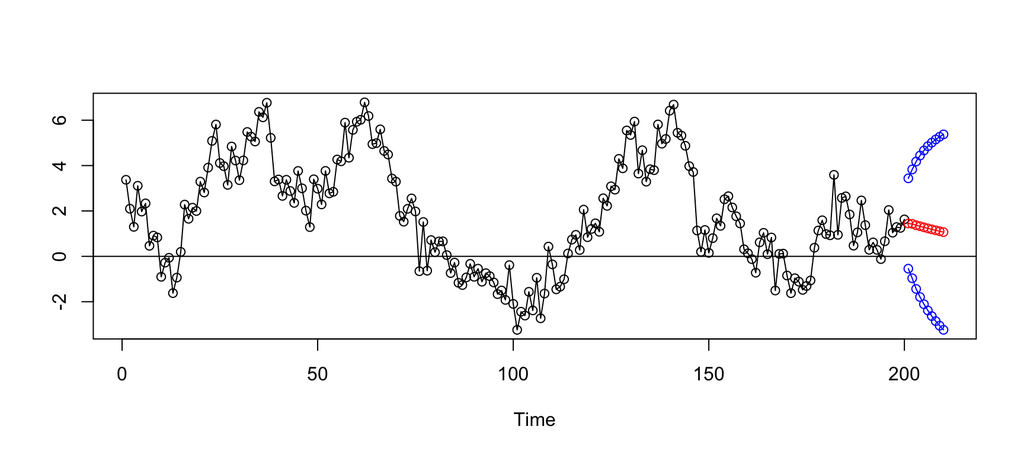

```r
  Xhat     <- X.forec$pred               # predicted mean
  Xhat.CIu <- Xhat + 1.96 * X.forec$se   # prediction upper CI
  Xhat.CIl <- Xhat - 1.96 * X.forec$se   # prediction lower CI

  # plot original TS with 10-step forecast and CI
  ts.plot(cbind(X, Xhat, Xhat.CIu, Xhat.CIl ), type="o", col=c("black","red","blue","blue"))
  abline(h=0)
```

# 4. Rolling 1-step prediction (Fixed Window Size)

- Suppose you have $X_1, \ldots, X_{180}$ to begin.
  - Separate $Y_t$ into two parts. Pretend that $X_1,\ldots, X_{100}$ is all you have, and hide the second part $\{X_{101}, \ldots, X_{180} \}$.
  - Use $\{X_1, \ldots, X_{100}\}$ to find fitting model. Say it was AR(2). Produce 1-step predicton $\{ \hat X_{101}\}$
  - Observe $X_{101}$
  - Use $\{X_2, \ldots, X_{101}\}$ to re-estimate parameters of AR(2). Then produce 1-step predicton $\{\hat X_{102}\}$
  - Observe $X_{102}$
  - Use $\{X_3, \ldots, X_{102}\}$ to re-estimate parameters of AR(2). Then produce 1-step predicton $\{\hat X_{103}\}$
  - Observe $X_{103}$
  - keep going
- Always using past 100 observation (Fixed Window Size) to predict the next obervation
- Fixed Start Rolling 1-step prediction will use $\{X_1, \ldots, X_{105}\}$ to predict $X_{106}$.